# Itroduction to Data science exercises

Neli Noykova

# Exercise set 1

# Exercise 1: preprocessing and general handling of the data.

## 1.1. Reading the data

Here we use part of the Titanic data described [here](https://www.kaggle.com/c/titanic/data). The data include information about the passangers on the board of the RMS Titanic. On April 15, 1912, during her maiden voyage, the Titanic sank after colliding with an iceberg, killing 1502 out of 2224 passengers and crew.

```r
titanic <- read.csv(file="train.csv",header=TRUE,sep=",",na.strings=c(""," ","NA"))
```

## 1.2. Have a look at the data.

Look at the dimension, structure and column names of the data:

```r
library(dplyr)
dim(titanic)
```

```
## [1] 891  12
```

```r
str(titanic)
```

```
## 'data.frame':    891 obs. of  12 variables:
##  $ PassengerId: int  1 2 3 4 5 6 7 8 9 10 ...
##  $ Survived   : int  0 1 1 1 0 0 0 0 1 1 ...
##  $ Pclass     : int  3 1 3 1 3 3 1 3 3 2 ...
##  $ Name       : Factor w/ 891 levels "Abbing, Mr. Anthony",..: 109 191 358 277 16 559 520 629 417 581 ...
##  $ Sex        : Factor w/ 2 levels "female","male": 2 1 1 1 2 2 2 2 1 1 ...
##  $ Age        : num  22 38 26 35 35 NA 54 2 27 14 ...
##  $ SibSp      : int  1 1 0 1 0 0 0 3 0 1 ...
##  $ Parch      : int  0 0 0 0 0 0 0 1 2 0 ...
##  $ Ticket     : Factor w/ 681 levels "110152","110413",..: 524 597 670 50 473 276 86 396 345 133 ...
##  $ Fare       : num  7.25 71.28 7.92 53.1 8.05 ...
##  $ Cabin      : Factor w/ 147 levels "A10","A14","A16",..: NA 82 NA 56 NA NA 130 NA NA NA ...
##  $ Embarked   : Factor w/ 3 levels "C","Q","S": 3 1 3 3 3 2 3 3 3 1 ...
```

```r
colnames(titanic)
```

```
##  [1] "PassengerId" "Survived"    "Pclass"      "Name"        "Sex"
##  [6] "Age"         "SibSp"       "Parch"       "Ticket"      "Fare"
## [11] "Cabin"       "Embarked"
```

```r
summary(titanic)
```

```
##   PassengerId       Survived          Pclass
##  Min.   :  1.0   Min.   :0.0000   Min.   :1.000
##  1st Qu.:223.5   1st Qu.:0.0000   1st Qu.:2.000
##  Median :446.0   Median :0.0000   Median :3.000
##  Mean   :446.0   Mean   :0.3838   Mean   :2.309
##  3rd Qu.:668.5   3rd Qu.:1.0000   3rd Qu.:3.000
##  Max.   :891.0   Max.   :1.0000   Max.   :3.000
##
##                                     Name         Sex           Age
##  Abbing, Mr. Anthony                  :  1   female:314   Min.   : 0.42
##  Abbott, Mr. Rossmore Edward          :  1   male  :577   1st Qu.:20.12
##  Abbott, Mrs. Stanton (Rosa Hunt)     :  1                Median :28.00
##  Abelson, Mr. Samuel                  :  1                Mean   :29.70
##  Abelson, Mrs. Samuel (Hannah Wizosky):  1                3rd Qu.:38.00
##  Adahl, Mr. Mauritz Nils Martin       :  1                Max.   :80.00
##  (Other)                              :885                NA's   :177
##      SibSp           Parch             Ticket         Fare
##  Min.   :0.000   Min.   :0.0000   1601    :  7   Min.   :  0.00
##  1st Qu.:0.000   1st Qu.:0.0000   347082  :  7   1st Qu.:  7.91
##  Median :0.000   Median :0.0000   CA. 2343:  7   Median : 14.45
##  Mean   :0.523   Mean   :0.3816   3101295 :  6   Mean   : 32.20
##  3rd Qu.:1.000   3rd Qu.:0.0000   347088  :  6   3rd Qu.: 31.00
##  Max.   :8.000   Max.   :6.0000   CA 2144 :  6   Max.   :512.33
##                                   (Other) :852
##          Cabin     Embarked
##  B96 B98    :  4   C   :168
##  C23 C25 C27:  4   Q   : 77
##  G6         :  4   S   :644
##  C22 C26    :  3   NA's:  2
##  D          :  3
##  (Other)    :186
##  NA's       :687
```

The original data involve 891 observations of 12 variables.

We will build new representations of the dataset that are better suited for a particular purpose. Some of the columns, e.g Name, simply identify a person and cannot be useful for prediction tasks - remove them.

I decided to delete the following columns: *Name*, *sibsp* (# of siblings / spouses aboard the Titanic, and *parch* (# of parents / children aboard the Titanic).

```r
keep <- c("PassengerId", "Survived", "Pclass", "Sex", "Age", "Ticket", "Fare", "Cabin")
tit <- select(titanic, one_of(keep))
glimpse(tit)
```

```
## Observations: 891
## Variables: 8
## $ PassengerId <int> 1, 2, 3, 4, 5, 6, 7, 8, 9, 10, 11, 12, 13, 14, 15,...
## $ Survived    <int> 0, 1, 1, 1, 0, 0, 0, 0, 1, 1, 1, 1, 0, 0, 0, 1, 0,...
## $ Pclass      <int> 3, 1, 3, 1, 3, 3, 1, 3, 3, 2, 3, 1, 3, 3, 3, 2, 3,...
## $ Sex         <fctr> male, female, female, female, male, male, male, m...
## $ Age         <dbl> 22, 38, 26, 35, 35, NA, 54, 2, 27, 14, 4, 58, 20, ...
## $ Ticket      <fctr> A/5 21171, PC 17599, STON/O2. 3101282, 113803, 37...
## $ Fare        <dbl> 7.2500, 71.2833, 7.9250, 53.1000, 8.0500, 8.4583, ...
## $ Cabin       <fctr> NA, C85, NA, C123, NA, NA, E46, NA, NA, NA, G6, C...
```

# 1.3. Take only the first character feom column Cabin and add it as a new column to the table.

```r
tit$Cab <- substr(tit$Cabin, 0, 1)
glimpse(tit)
```

```
## Observations: 891
## Variables: 9
## $ PassengerId <int> 1, 2, 3, 4, 5, 6, 7, 8, 9, 10, 11, 12, 13, 14, 15,...
## $ Survived    <int> 0, 1, 1, 1, 0, 0, 0, 0, 1, 1, 1, 1, 0, 0, 0, 1, 0,...
## $ Pclass      <int> 3, 1, 3, 1, 3, 3, 1, 3, 3, 2, 3, 1, 3, 3, 3, 2, 3,...
## $ Sex         <fctr> male, female, female, female, male, male, male, m...
## $ Age         <dbl> 22, 38, 26, 35, 35, NA, 54, 2, 27, 14, 4, 58, 20, ...
## $ Ticket      <fctr> A/5 21171, PC 17599, STON/O2. 3101282, 113803, 37...
## $ Fare        <dbl> 7.2500, 71.2833, 7.9250, 53.1000, 8.0500, 8.4583, ...
## $ Cabin       <fctr> NA, C85, NA, C123, NA, NA, E46, NA, NA, NA, G6, C...
## $ Cab         <chr> NA, "C", NA, "C", NA, NA, "E", NA, NA, NA, "G", "C...
```

# 1.4. Transform string to categorical column values.

You’ll notice that some of the columns, such as the previously added deck number are categorical. Their representation as a string is not efficient for further computation. Transform them into numeric values so that a unique integer id corresponds to each distinct category. Hint. pandas can do this for you.

```r
tit$Cab <- as.factor(tit$Cab)
glimpse(tit)
```

```
## Observations: 891
## Variables: 9
## $ PassengerId <int> 1, 2, 3, 4, 5, 6, 7, 8, 9, 10, 11, 12, 13, 14, 15,...
## $ Survived    <int> 0, 1, 1, 1, 0, 0, 0, 0, 1, 1, 1, 1, 0, 0, 0, 1, 0,...
## $ Pclass      <int> 3, 1, 3, 1, 3, 3, 1, 3, 3, 2, 3, 1, 3, 3, 3, 2, 3,...
## $ Sex         <fctr> male, female, female, female, male, male, male, m...
## $ Age         <dbl> 22, 38, 26, 35, 35, NA, 54, 2, 27, 14, 4, 58, 20, ...
## $ Ticket      <fctr> A/5 21171, PC 17599, STON/O2. 3101282, 113803, 37...
## $ Fare        <dbl> 7.2500, 71.2833, 7.9250, 53.1000, 8.0500, 8.4583, ...
## $ Cabin       <fctr> NA, C85, NA, C123, NA, NA, E46, NA, NA, NA, G6, C...
## $ Cab         <fctr> NA, C, NA, C, NA, NA, E, NA, NA, NA, G, C, NA, NA...
```

# 1.5. Imputation of the missing data

Some of the rows in the data have missing values, e.g when the cabin number of a person is not known. Most machine learning algorithms have trouble with missing values, and they need to be handled in preprocessing:

# a) For continous values, replace the missing values with the average of the non-missing values of that column.

The following ifelse() function returns the imputed mean value if its first argument is NA. Otherwise, it returns the first argument:

```r
tit$Age <- ifelse(is.na(tit$Age), mean(tit$Age, na.rm=TRUE), tit$Age)
glimpse(tit)
```

```
## Observations: 891
## Variables: 9
## $ PassengerId <int> 1, 2, 3, 4, 5, 6, 7, 8, 9, 10, 11, 12, 13, 14, 15,...
## $ Survived    <int> 0, 1, 1, 1, 0, 0, 0, 0, 1, 1, 1, 1, 0, 0, 0, 1, 0,...
## $ Pclass      <int> 3, 1, 3, 1, 3, 3, 1, 3, 3, 2, 3, 1, 3, 3, 3, 2, 3,...
## $ Sex         <fctr> male, female, female, female, male, male, male, m...
## $ Age         <dbl> 22.00000, 38.00000, 26.00000, 35.00000, 35.00000, ...
## $ Ticket      <fctr> A/5 21171, PC 17599, STON/O2. 3101282, 113803, 37...
## $ Fare        <dbl> 7.2500, 71.2833, 7.9250, 53.1000, 8.0500, 8.4583, ...
## $ Cabin       <fctr> NA, C85, NA, C123, NA, NA, E46, NA, NA, NA, G6, C...
## $ Cab         <fctr> NA, C, NA, C, NA, NA, E, NA, NA, NA, G, C, NA, NA...
```

# b) For discrete and categorical values, replace the missing values with the mode of the column.

```r
library(Hmisc)
tit$Cabin <- impute(tit$Cabin, mean)
tit$Cab <- impute(tit$Cab, mean)
glimpse(tit)
```

```
## Observations: 891
## Variables: 9
## $ PassengerId <int> 1, 2, 3, 4, 5, 6, 7, 8, 9, 10, 11, 12, 13, 14, 15,...
## $ Survived    <int> 0, 1, 1, 1, 0, 0, 0, 0, 1, 1, 1, 1, 0, 0, 0, 1, 0,...
## $ Pclass      <int> 3, 1, 3, 1, 3, 3, 1, 3, 3, 2, 3, 1, 3, 3, 3, 2, 3,...
## $ Sex         <fctr> male, female, female, female, male, male, male, m...
## $ Age         <dbl> 22.00000, 38.00000, 26.00000, 35.00000, 35.00000, ...
## $ Ticket      <fctr> A/5 21171, PC 17599, STON/O2. 3101282, 113803, 37...
## $ Fare        <dbl> 7.2500, 71.2833, 7.9250, 53.1000, 8.0500, 8.4583, ...
## $ Cabin       <fctr> B96 B98, C85, B96 B98, C123, B96 B98, B96 B98, E4...
## $ Cab         <fctr> C, C, C, C, C, C, E, C, C, C, G, C, C, C, C, C, C...
```

# 1.6. Exporting the data as .csv and .json formats.

# Exprort the data as .csv file

```r
write.csv(tit, file = "titCsv.csv")
```

# Exprort the data as .json file

```r
library(rjson)
titJson <- toJSON(unname(split(tit, 1:nrow(tit))))
cat(titJson)
```

```
## [{"PassengerId":1,"Survived":0,"Pclass":3,"Sex":"male","Age":22,"Ticket":"A/5 21171","Fare":7.25,"Cabin":"B96 B98","Cab":"C"},{"PassengerId":2,"Survived":1,"Pclass":1,"Sex":"female","Age":38,"Ticket":"PC 17599","Fare":71.2833,"Cabin":"C85","Cab":"C"},{"PassengerId":3,"Survived":1,"Pclass":3,"Sex"…
```

The created .json data format is different than the structure required in the exercises set:

[ { “Deck”: 0, “Age”: 20, “Survived”, 0 … }, { … }]

**Conclusion:** R is niot the best language for creating, editing and saving .json files. Therefore I continue the work in Python. The code for producing .json file is:

```
import csv
import json

#convert .csv to .json in Python.

# Open the CSV
f = open( 'titCsv.csv', 'rU' )
# Change each fieldname to the appropriate field name. I know, so difficult.
reader = csv.DictReader( f, fieldnames = ( "PasengerID","Survived","Pclass","Sex","Age","Ticket","Fare","Cabin","Cab" ))
# Parse the CSV into JSON
out = json.dumps( [ row for row in reader ] )
print ("JSON parsed!")
# Save the JSON
f = open( 'parsed.json', 'w')
f.write(out)
print ("JSON saved!")
```

The output file parsed.json is imported and checked in R.

```r
result <- fromJSON(file = "parsed.json")
```

The result is worse than the previous one, obtained in R.

# Exercise 2: Text data.

We’ll are looking into Amazon reviews, and the steps needed to transform a raw dataset into one more suitable for prediction tasks.

# 2.1 Download the data in .json format.

```r
result <- fromJSON(file = "Automotive_5.json")
print(result)
```

```
## $reviewerID
## [1] "A3F73SC1LY51OO"
##
## $asin
## [1] "B00002243X"
##
## $reviewerName
## [1] "Alan Montgomery"
##
## $helpful
## [1] 4 4
##
## $reviewText
## [1] "I needed a set of jumper cables for my new car and these had good reviews and were at a good price.  They have been used a few times already and do what they are supposed to - no complaints there.What I will say is that 12 feet really isn't an ideal length.  Sure, if you pull up front bumper…
##
## $overall
## [1] 5
##
## $summary
## [1] "Work Well - Should Have Bought Longer Ones"
##
## $unixReviewTime
## [1] 1313539200
##
## $reviewTime
## [1] "08 17, 2011"
```

It seems that the reading did not succeed, and only the first json object was read.

Useful library for dealing with .json objects . The tutorial is given [here](https://cran.r-project.org/web/packages/tidyjson/vignettes/introduction-to-tidyjson.html) eBook about handling and processing strings in R [here](http://gastonsanchez.com/Handling_and_Processing_Strings_in_R.pdf)

# 2.2 Downcase the contents, remove all punctuation and stop-words in the reviewText field

```r
library(tm)
textBeg<-result[['reviewText']]
textBeg <- result$reviewText
textBeg = tolower(textBeg) #make it lower case
textBeg
```

```
## [1] "i needed a set of jumper cables for my new car and these had good reviews and were at a good price.  they have been used a few times already and do what they are supposed to - no complaints there.what i will say is that 12 feet really isn't an ideal length.  sure, if you pull up front bumper…
```

```r
textBeg = gsub('[[:punct:]]', '', textBeg) #remove punctuation
textBeg
```

```
## [1] "i needed a set of jumper cables for my new car and these had good reviews and were at a good price  they have been used a few times already and do what they are supposed to  no complaints therewhat i will say is that 12 feet really isnt an ideal length  sure if you pull up front bumper to fr…
```

```r
#remove stop-words
stopwords_regex = paste(stopwords('en'), collapse = '\\b|\\b')
stopwords_regex = paste0('\\b', stopwords_regex, '\\b')
textBeg = stringr::str_replace_all(textBeg, stopwords_regex, '')
textBeg
```

```
## [1] " needed  set  jumper cables   new car    good reviews     good price     used   times already      supposed    complaints therewhat  will say   12 feet really isnt  ideal length  sure   pull  front bumper  front bumper   plenty long   lot  times  will  beside another car  cant get really clo…
```

4. Apply a stemmer on the paragraphs, so that inflected forms are mapped to the base form. For example, for python the popular natural language toolkit nltk has an easy-to-use stemmer.
5. Filter the data by selecting reviews where the field overall is 4 or 5, and store the review texts in file pos.txt. Similarly, select reviews with rating 1 or 2 and store the reviews in file neg.txt. (Ignore the reviews with overall rating 3.) Each line in the two files should contain exactly one preprocessed review text without the rating. Having created two collections of positive and negative reviews, respectively, you may wish to take a quick look to see how the review texts differ between them. Here too, we will be using this data later to experiment with machine learning methods.

# Exercise 3: SQL data (Baseball).

## 3.1. Reading the data

This exercise involves an SQL database with historical data on baseball players.First I download the sqlite version of the dataset from Kaggle and unzip in sepatrate data directory. For further analysis I have used RSQLite and DBI packages in R. Connection with the database and list of the tables involved is provided as:

```r
library("RSQLite")
library(DBI)
drv <- dbDriver("SQLite")
con <- dbConnect(drv, dbname = "database.sqlite")
dbListTables(con)
```

```
##  [1] "all_star"            "appearances"         "batting"
##  [4] "batting_postseason"  "both"                "college"
##  [7] "fielding"            "fielding_outfield"   "fielding_postseason"
## [10] "hall_of_fame"        "home_game"           "manager"
## [13] "manager_award"       "manager_award_vote"  "manager_half"
## [16] "park"                "pitching"            "pitching_postseason"
## [19] "player"              "player_award"        "player_award_vote"
## [22] "player_college"      "postseason"          "salary"
## [25] "team"                "team_franchise"      "team_half"
```

```r
dbListFields(con, "player")
```

```
##  [1] "player_id"     "birth_year"    "birth_month"   "birth_day"
##  [5] "birth_country" "birth_state"   "birth_city"    "death_year"
##  [9] "death_month"   "death_day"     "death_country" "death_state"
## [13] "death_city"    "name_first"    "name_last"     "name_given"
## [17] "weight"        "height"        "bats"          "throws"
## [21] "debut"         "final_game"    "retro_id"      "bbref_id"
```

# 3.2 Join the tables player and hall_of_fame by the key player_id which appears in both. Select the rows where the field inducted takes value ‘Y’ (i.e., those entries where the player in question was voted to the Hall of Fame).

We get 312 famous players, including Babe Ruth and Yogi Berra.

```r
joinedresults <- dbSendQuery(con, "SELECT * FROM
player INNER JOIN hall_of_fame USING(player_id) WHERE inducted = 'Y'")
fetch(joinedresults)
```

```
##     player_id birth_year birth_month birth_day  birth_country
## 1    cobbty01       1886          12        18            USA
## 2    ruthba01       1895           2         6            USA
## 3   wagneho01       1874           2        24            USA
## 4   mathech01       1880           8        12            USA
## 5   johnswa01       1887          11         6            USA
## 6   lajoina01       1874           9         5            USA
## 7   speaktr01       1888           4         4            USA
## 8   youngcy01       1867           3        29            USA
## 9   bulkemo99       1837          12        26            USA
## 10  johnsba99       1865           1         5            USA
## 11   mackco01       1862          12        22            USA
## 12  mcgrajo01       1873           4         7            USA
## 13  wrighge01       1847           1        28            USA
## 14  alexape01       1887           2        26            USA
```

[output cut: 1863 more lines]

```r
dbDisconnect(con)
```

# 3.3. Join in a third table, player_college, again by the key player_id. The player_college table indicates for which college (university) the player has played, if any, in each year.

The number of rows in the table player_college per player varies between zero and nine.

We have to Keep the restriction that the player should have been selected to the Hall of Fame (inducted = ‘Y’), and group the output by college (college_id).

```r
drv <- dbDriver("SQLite")
con <- dbConnect(drv, dbname = "database.sqlite")
#list the tables in the database
dbListTables(con)
```

```
##  [1] "all_star"            "appearances"         "batting"
##  [4] "batting_postseason"  "both"                "college"
##  [7] "fielding"            "fielding_outfield"   "fielding_postseason"
## [10] "hall_of_fame"        "home_game"           "manager"
## [13] "manager_award"       "manager_award_vote"  "manager_half"
## [16] "park"                "pitching"            "pitching_postseason"
## [19] "player"              "player_award"        "player_award_vote"
## [22] "player_college"      "postseason"          "salary"
## [25] "team"                "team_franchise"      "team_half"
```

```r
joined <-dbSendQuery(con, "SELECT DISTINCT * from (SELECT * FROM
player INNER JOIN hall_of_fame USING(player_id) WHERE inducted = 'Y') INNER JOIN player_college USING(player_id) WHERE inducted = 'Y' GROUP BY college_id")
fetch(joined)
```

```
##    player_id birth_year birth_month birth_day birth_country birth_state
## 1  seweljo01       1898          10         9           USA          AL
## 2  jacksre01       1946           5        18           USA          PA
## 3  thomafr04       1968           5        27           USA          GA
## 4  lyonste01       1900          12        28           USA          LA
## 5  cochrmi01       1903           4         6           USA          MA
## 6  puckeki01       1960           3        14           USA          IL
## 7  mathech01       1880           8        12           USA          PA
## 8  seaveto01       1944          11        17           USA          CA
## 9  gillipa99       1937           8        22           USA          CA
## 10 smithoz01       1954          12        26           USA          AL
## 11 morgajo02       1943           9        19           USA          TX
## 12 willidi02       1929           5         7           USA          MO
## 13 koufasa01       1935          12        30           USA          NY
## 14 gehrilo01       1903           6        19           USA          NY
```

[output cut: 333 more lines]

```r
dbDisconnect(con)
```

Next we have to count how many Hall of Fame players are alumni of each college. There is one college that has as many as three. Which one? (To see the full name of the college, you can look up the college_id in table college). This is better to be provided in Python.

# Exercise set 2

# Exercise 1: Exploratory data analysis

Here we continue to study the Titanic data set from Week 1 (Exercise 1).

We use the preprocessed data during Week 1. The columns Name and Ticket are excluded from dataset because they are not related to the analysis. I also remove the column PassengerId from the data set since it is not useful for the further statistical analysis.

```r
library(dplyr)

titanic <- read.csv(file="testOut.csv",header=TRUE,sep=",")
keep <- c("Survived", "Pclass", "Sex", "Age", "SibSp", "Parch", "Fare", "Cabin", "Embarked")
titanic <- select(titanic, one_of(keep))
```

# 1.1 Add average values at the last row of the dataframe

```
#initially set the ast row to be the same as row=890
data.loc[892,:] = data.loc[890,:]
col_names= ["Survived","Sex", "Embarked", "Cabin", "PassengerId", "Pclass", "Age", "SibSp", "Parch", "Fare"]
print("Average Joe:")

for val in col_names:
    #for categorical columns take mode
 if (val == "Sex" or val == "Embarked" or val == "Cabin" ):
     data[892,val] = data[val].mode()
 #for numerical columns take median
 else:
     data[892,val] = data[val].median()

 #dataA = concat(data, averageJoe)
 data.tail(n=5)
```

Last row represent the “Average Joe” on board of the ship. who is male at age about 30 and did not survived. The values of other variables at the last row: Pclass = 3, SibSp = 0, Parch = 0, Fare = 14.45, Cabin = 75, Embarked = 2.

# 1.2 Take subsets SurvivorJane and NonsurvivorJoe

Subset of survived females is formed as:

```
Female= data["Sex"] > 0
Female.head(5)
Survived = data["Survived"] >0
Survived.head(5)
SurvivorJane = data[Female & Survived]
```

Subsed of non-survived males is taken as:

```
Male= data["Sex"] < 1
Male.head(5)
NonSurvivor = data["Survived"] < 1
NonSurvivorJoe = data[Male & NonSurvivor]
```

# 1.3 Exploratory analysis of the subsets SurvivorJane and NonsurvivorJoe

I remove the column PassengerId from both subsests as it does not provide useful statistical information.

```r
SurvivorJane <- read.csv(file="SurvivorJane.csv",header=TRUE,sep=",")
#remove PassingerID
keep <- c("Survived", "Pclass", "Sex", "Age", "SibSp", "Parch", "Fare", "Cabin", "Embarked")
SurvivorJane <- select(SurvivorJane, one_of(keep))
dim(SurvivorJane)
```

```
## [1] 233   9
```

```r
summary(SurvivorJane)
```

```
##     Survived     Pclass           Sex         Age            SibSp
##  Min.   :1   Min.   :1.000   Min.   :0   Min.   : 0.75   Min.   :0.000
##  1st Qu.:1   1st Qu.:1.000   1st Qu.:0   1st Qu.:22.00   1st Qu.:0.000
##  Median :1   Median :2.000   Median :0   Median :29.70   Median :0.000
##  Mean   :1   Mean   :1.918   Mean   :0   Mean   :28.98   Mean   :0.515
##  3rd Qu.:1   3rd Qu.:3.000   3rd Qu.:0   3rd Qu.:35.00   3rd Qu.:1.000
##  Max.   :1   Max.   :3.000   Max.   :0   Max.   :63.00   Max.   :4.000
##      Parch            Fare             Cabin           Embarked
##  Min.   :0.000   Min.   :  7.225   Min.   :  2.00   Min.   :0.000
##  1st Qu.:0.000   1st Qu.: 13.000   1st Qu.: 75.00   1st Qu.:0.000
##  Median :0.000   Median : 26.000   Median : 75.00   Median :2.000
##  Mean   :0.515   Mean   : 51.939   Mean   : 75.98   Mean   :1.335
##  3rd Qu.:1.000   3rd Qu.: 76.292   3rd Qu.: 75.00   3rd Qu.:2.000
##  Max.   :5.000   Max.   :512.329   Max.   :145.00   Max.   :2.000
```

```r
NonSurvivorJoe <- read.csv(file="NonSurvivorJoe.csv",header=TRUE,sep=",")
#remove PassingerID
NonSurvivorJoe <- select(NonSurvivorJoe, one_of(keep))
dim(NonSurvivorJoe)
```

```
## [1] 468   9
```

```r
summary(NonSurvivorJoe)
```

```
##     Survived     Pclass           Sex         Age            SibSp
##  Min.   :0   Min.   :1.000   Min.   :1   Min.   : 1.00   Min.   :0.0000
##  1st Qu.:0   1st Qu.:2.000   1st Qu.:1   1st Qu.:24.00   1st Qu.:0.0000
##  Median :0   Median :3.000   Median :1   Median :29.70   Median :0.0000
##  Mean   :0   Mean   :2.476   Mean   :1   Mean   :31.18   Mean   :0.4402
##  3rd Qu.:0   3rd Qu.:3.000   3rd Qu.:1   3rd Qu.:36.00   3rd Qu.:0.0000
##  Max.   :0   Max.   :3.000   Max.   :1   Max.   :74.00   Max.   :8.0000
##      Parch             Fare             Cabin           Embarked
##  Min.   :0.0000   Min.   :  0.000   Min.   :  0.00   Min.   :0.000
##  1st Qu.:0.0000   1st Qu.:  7.796   1st Qu.: 75.00   1st Qu.:2.000
##  Median :0.0000   Median :  9.417   Median : 75.00   Median :2.000
##  Mean   :0.2073   Mean   : 21.961   Mean   : 74.53   Mean   :1.637
##  3rd Qu.:0.0000   3rd Qu.: 26.000   3rd Qu.: 75.00   3rd Qu.:2.000
##  Max.   :5.0000   Max.   :263.000   Max.   :146.00   Max.   :2.000
```

First look the distributions of all variables of the whole data set. Different colors are according the Sex column.

```r
library(GGally)
```

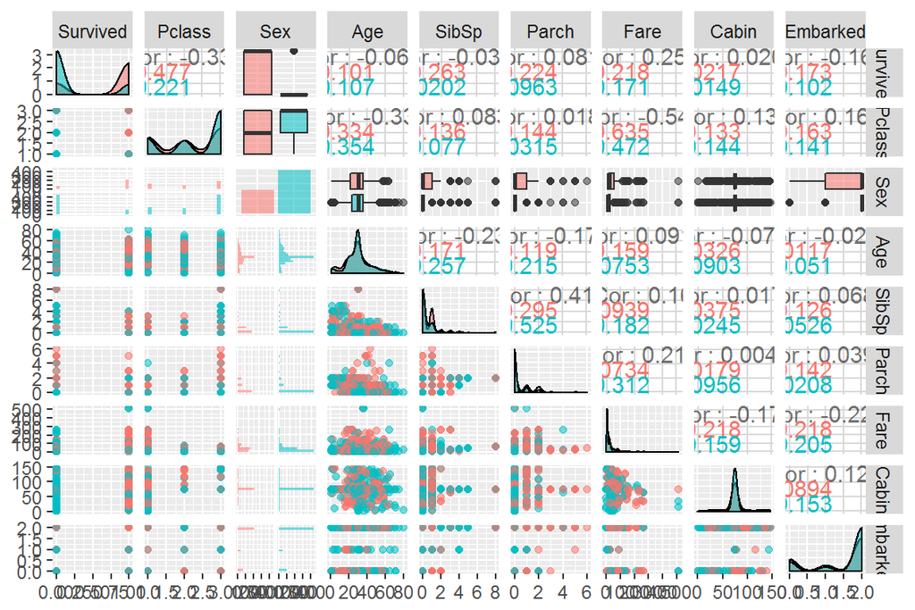

```r
library(ggplot2)
titanic$Sex <- as.factor(titanic$Sex)
pTitanic <- ggpairs(titanic, mapping = aes(col=Sex, alpha=0.3), lower = list(combo = wrap("facethist", bins = 20)))
pTitanic
```

Another presentation of correlation plot:

```r
#another presentation of correlation matrix
titanic$Sex <- as.numeric(titanic$Sex)
titanic$Survived <- as.numeric(titanic$Survived)
cor_matrix<-cor(titanic) %>% round(digits =2)
cor_matrix
```

```
##          Survived Pclass   Sex   Age SibSp Parch  Fare Cabin Embarked
## Survived     1.00  -0.34 -0.54 -0.07 -0.04  0.08  0.26  0.02    -0.17
## Pclass      -0.34   1.00  0.13 -0.33  0.08  0.02 -0.55  0.13     0.16
## Sex         -0.54   0.13  1.00  0.08 -0.11 -0.25 -0.18 -0.04     0.11
## Age         -0.07  -0.33  0.08  1.00 -0.23 -0.18  0.09 -0.07    -0.03
## SibSp       -0.04   0.08 -0.11 -0.23  1.00  0.41  0.16  0.02     0.07
## Parch        0.08   0.02 -0.25 -0.18  0.41  1.00  0.22  0.00     0.04
## Fare         0.26  -0.55 -0.18  0.09  0.16  0.22  1.00 -0.18    -0.22
## Cabin        0.02   0.13 -0.04 -0.07  0.02  0.00 -0.18  1.00     0.12
## Embarked    -0.17   0.16  0.11 -0.03  0.07  0.04 -0.22  0.12     1.00
```

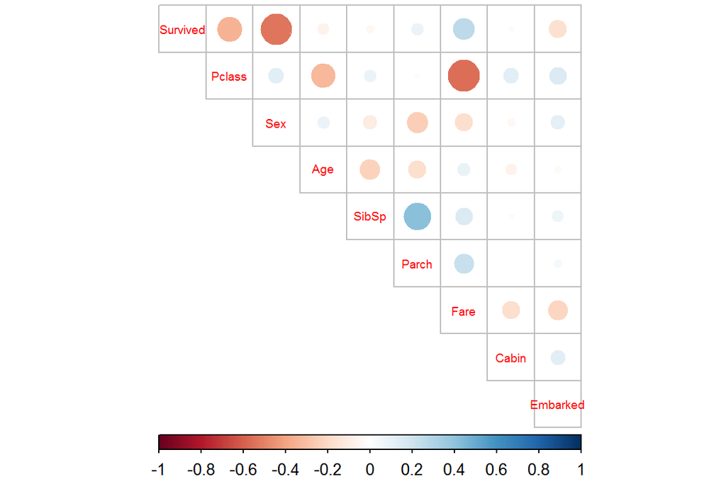

```r
library(corrplot)
corrplot(cor_matrix, method="circle", type = "upper", cl.pos = "b", tl.pos = "d", tl.cex = 0.6)
```

The correlation matrix suggests a high negative correlation between survived and Sex, and Pclass and Fare.

The distributions of the variables in *survivalJane* subgroup:

[output not shown]

[output cut: 115 more lines]

[output not shown]

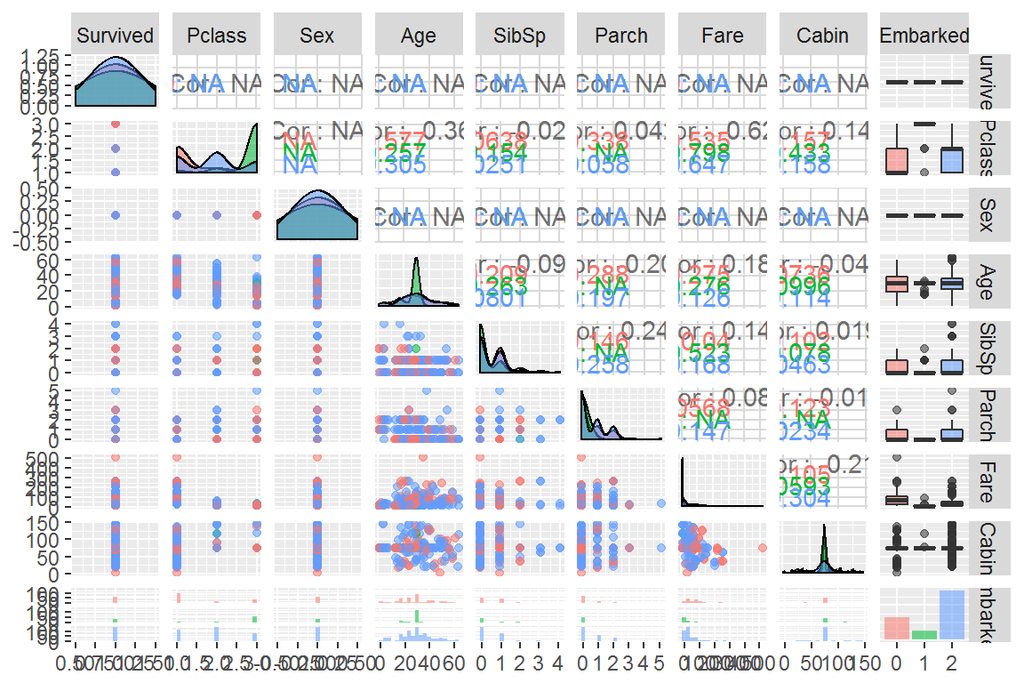

```r
SurvivorJane$Embarked <- as.factor(SurvivorJane$Embarked)
pJane <- ggpairs(SurvivorJane, mapping = aes(col=Embarked, alpha=0.3), lower = list(combo = wrap("facethist", bins = 20)))
pJane
```

Correlation matrix of this subset suggests high negative correlation between Pclass and Fare:

```r
SurvivorJane$Embarked <- as.numeric(SurvivorJane$Embarked)
cor_matrix<-cor(SurvivorJane) %>% round(digits =2)
cor_matrix
```

```
##          Survived Pclass Sex   Age SibSp Parch  Fare Cabin Embarked
## Survived        1     NA  NA    NA    NA    NA    NA    NA       NA
## Pclass         NA   1.00  NA -0.37 -0.03  0.04 -0.63  0.15     0.11
## Sex            NA     NA   1    NA    NA    NA    NA    NA       NA
## Age            NA  -0.37  NA  1.00 -0.10 -0.20  0.18 -0.04     0.02
## SibSp          NA  -0.03  NA -0.10  1.00  0.24  0.14  0.02     0.01
## Parch          NA   0.04  NA -0.20  0.24  1.00  0.09 -0.02     0.11
## Fare           NA  -0.63  NA  0.18  0.14  0.09  1.00 -0.22    -0.23
## Cabin          NA   0.15  NA -0.04  0.02 -0.02 -0.22  1.00     0.09
## Embarked       NA   0.11  NA  0.02  0.01  0.11 -0.23  0.09     1.00
```

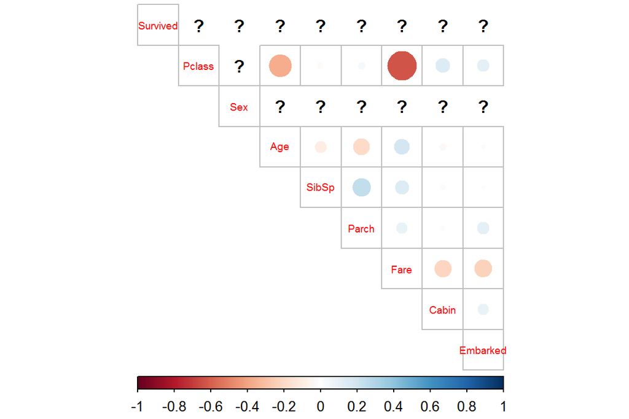

```r
corrplot(cor_matrix, method="circle", type = "upper", cl.pos = "b", tl.pos = "d", tl.cex = 0.6)
```

The distributions of the variables in *Non-survival Joe* subgroup:

[output not shown]

[output cut: 100 more lines]

[output not shown]

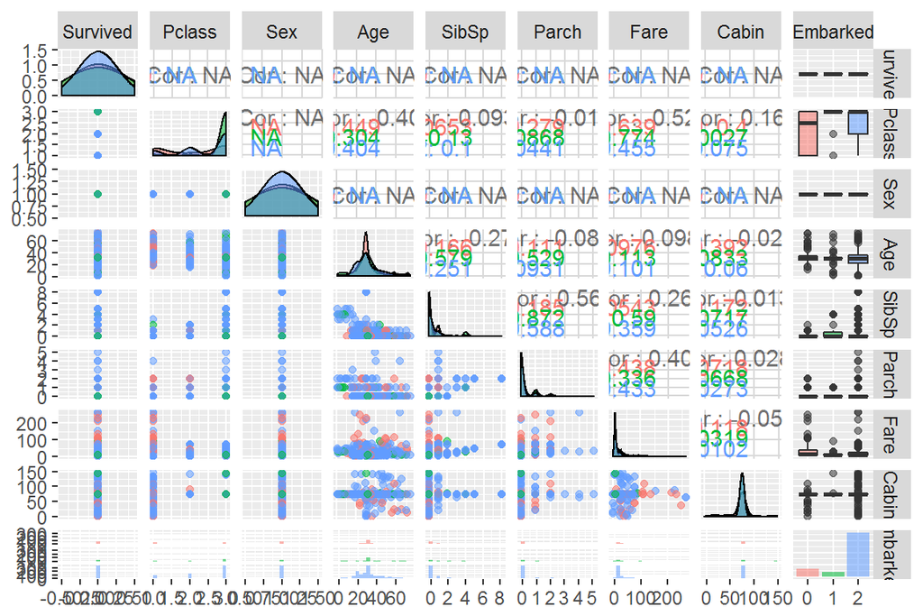

```r
NonSurvivorJoe$Embarked <- as.factor(NonSurvivorJoe$Embarked)
pJoe <- ggpairs(NonSurvivorJoe, mapping = aes(col=Embarked, alpha=0.3), lower = list(combo = wrap("facethist", bins = 20)))
pJoe
```

The correlation matrix of this subset shows high negative correlation between Pclass and Fare, and high positive corellation between SibSp and Parch.

```r
NonSurvivorJoe$Embarked <- as.numeric(NonSurvivorJoe$Embarked)
cor_matrix<-cor(NonSurvivorJoe) %>% round(digits =2)
cor_matrix
```

```
##          Survived Pclass Sex   Age SibSp Parch  Fare Cabin Embarked
## Survived        1     NA  NA    NA    NA    NA    NA    NA       NA
## Pclass         NA   1.00  NA -0.40  0.09 -0.01 -0.53  0.16     0.12
## Sex            NA     NA   1    NA    NA    NA    NA    NA       NA
## Age            NA  -0.40  NA  1.00 -0.28 -0.09  0.10 -0.03    -0.05
## SibSp          NA   0.09  NA -0.28  1.00  0.56  0.27  0.01     0.06
## Parch          NA  -0.01  NA -0.09  0.56  1.00  0.40  0.03     0.01
## Fare           NA  -0.53  NA  0.10  0.27  0.40  1.00 -0.05    -0.17
## Cabin          NA   0.16  NA -0.03  0.01  0.03 -0.05  1.00     0.12
## Embarked       NA   0.12  NA -0.05  0.06  0.01 -0.17  0.12     1.00
```

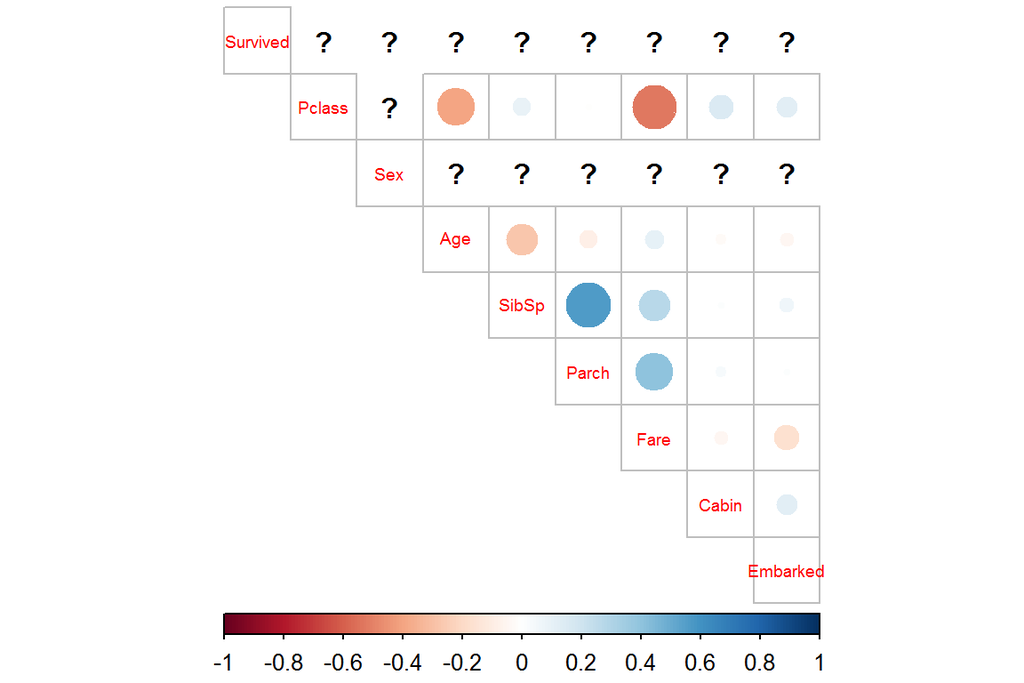

```r
corrplot(cor_matrix, method="circle", type = "upper", cl.pos = "b", tl.pos = "d", tl.cex = 0.6)
```